# R筆記 – (17)獨立成份分析(ICA)

skydome20

2018/03/03

[返回主目錄](https://rpubs.com/skydome20/Table)

#### Co-authors: [Jeff Hung](https://rpubs.com/jeff_datascience/DS_Notebook)

# 本篇目錄

0. 簡言
1. 獨立成份分析
2. ICA-訊號處理
   - 模擬雞尾酒會
   - FastICA-Algorithm
   - 選擇多少個來源訊號的數量？
3. 總結
4. Reference
5. R and packages version

## 0. 簡言

在談論有關於降維(Dimension Reduction)的方法時，獨立成份分析(Independent Component Analysis, ICA)跟主成份分析(Principal Component Analysis)常常會一起被討論。

先回想一下，所謂的主成份分析(PCA)，就是將手中的原始資料，從高維空間投影到低維空間，期望此投影資料在低維空間中具有最大的變異(Variance)。做法上，會利用特徵值跟特徵向量，將原始變數(original variables)做線性組合(linear combination)，所產生的components便能最大化解釋原始資料的變異量。

而獨立成份分析(ICA)，會先假設手中的資料其實有經過混合(例如，多個彼此獨立的分配，混合成手中的資料)，因此期望能夠從手中的資料，回推出是哪些獨立的分配。

若以食物來比喻，就是你現在正在品嘗一道菜，並試圖辨識出裡面使用了哪些調味料跟哪些食材。

兩種都是屬於降維的方法，但概念上截然不同。若以食物比喻兩者概念的話：

1. 主成份分析(PCA)：「你現在手中有各種調味料跟食材，那要如何搭配比例，才能做出最美味的一道菜」；
2. 獨立成份分析(ICA)：「你現在正在品嘗一道菜，並試圖辨識出裡面使用了哪些調味料跟哪些食材。」

當然，降維的方法還有很多：SVD，LLE，LDA，QDA，Laplacian Eigenmaps，t-SNE…等等，日後有機會再討論。

## 1. 獨立成份分析

當你開始研究ICA時，一定會知道的案例就是「雞尾酒會問題(Cocktail-Party Problem)」。

這個問題本來是源自於心理學，他們稱作「[雞尾酒會效應](https://info.babyhome.com.tw/article/1688)」，研究的是人類為何能在一片吵雜的雞尾酒會中，依然能專注於自己想聽的那個談話，或是某些特殊聲音(例如，遠方忽然有人用自己的母語在交談)。這個問題從心理學、聽覺、以及腦科學的角度，解釋人類的「聽力選擇能力」。

來到電腦科學的時代時，人類就開始好奇，有沒有辦法也讓電腦獲得這種辨識能力？基於此動機，並搭配統計學的理論，所發展出來的模型就是獨立成份分析(ICA)，其概念基本上可以用下圖來解釋：

[figure not shown]

在做資料分析時，手上的資料**x**基本上都是「蒐集而來的」，也就是對應圖中的「麥克風」。

「麥克風」所蒐集到的資料，可以視為從多個來源(Soucre, **s**)而來，並且經過某些疊加/組合的過程(**A**)，最後成為最後手中的資料(**x**)，所以可以寫成以下公式：`x = As`。

ICA的做法，就是試圖「從**x**回推到**s**」。

## 2. ICA-訊號處理

### 模擬雞尾酒會

首先，我們就先模擬一下雞尾酒會的簡化版：「只有兩個音源，以及兩支麥克風。」

先產生兩組原始音源訊號(**S**)，分別是sin函數跟鋸齒函數。

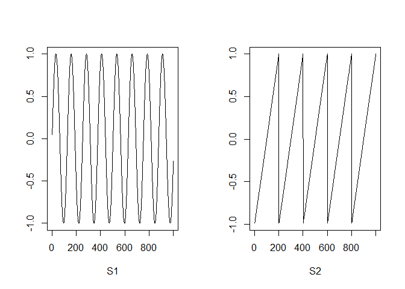

```r
S <- cbind(sin((1:1000)/20),
           rep((((1:200)-100)/100), 5)
           )

par(mfcol = c(1, 2))
plot(1:1000, S[,1], type = "l",xlab = "S1", ylab = "")   # sin函數
plot(1:1000, S[,2], type = "l", xlab = "S2", ylab = "")  # 鋸齒函數
```

接著建構一個混合矩陣(A)，可以想像這是混合這兩組訊號的權重。

```r
# Mixing matrix (混合矩陣)
A <- matrix(c(0.291, 0.6557, -0.5439, 0.5572), 2, 2)
A
```

```
##        [,1]    [,2]
## [1,] 0.2910 -0.5439
## [2,] 0.6557  0.5572
```

這時，可以想像有兩支麥克風接收混合後的新訊號，也就是**X**：

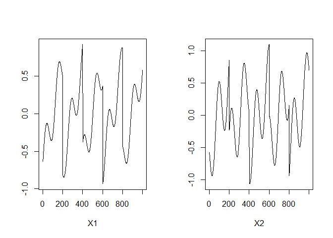

```r
# 新訊號
X <- S %*% A

par(mfcol = c(1, 2))
plot(1:1000, X[,1], type = "l",xlab = "X1", ylab = "")
plot(1:1000, X[,2], type = "l", xlab = "X2", ylab = "")
```

### FastICA-Algorithm

[FastICA](https://www.cs.helsinki.fi/u/ahyvarin/papers/fastica.shtml) 是由 Aapo Hyvärinen 所提出， 如今最廣泛、也最有效率的獨立成份分析演算法。

在使用時，提到有兩個強假設要遵守(詳情請參閱上面之資源)：

1. 來源訊號/資料間彼此之間獨立
2. 來源訊號/資料不可以為常態分布

由於 FastICA 在運算時，會使用最大化的kurtosis(峰度)來判斷來源訊號/資料，因此常態分布的資料 kurtosis 為 0 ，在運算上就會被自動排除。至於獨立的部份，想必不用多說。

在R的操作上，剛好就有`fastICA`套件可以實踐此演算法：

```r
require(fastICA)
```

再來，只要拿先前模擬的資料**X**，丟入`fastICA()`，便可以進行獨立成份分析。

在使用上，參數的設定跟FastICA中的演算法有關，若想深入了解如何設定參數，建議先理解演算法後，再根據 Help Document 來設定。(基本會需要 neg-entropy、kurtosis 等統計知識)

若只是想簡單應用，可以直接使用預設值(default)，並留意來源訊號/資料的數量，以`n.comp`來設定：

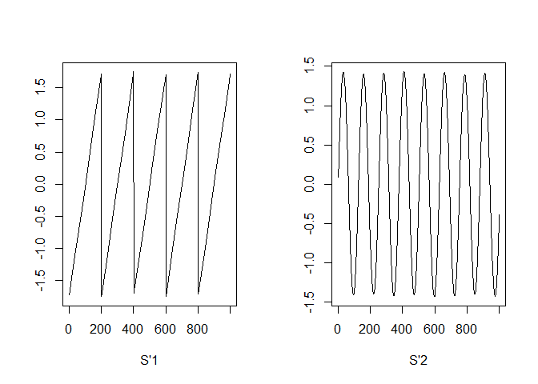

```r
# ICA for extracting independent sources from mixed signals
ICA_result = fastICA(X, n.comp = 2)

# 以下兩個就是ICA萃取出的來源
S1_extracted = ICA_result$S[, 1]
S2_extracted = ICA_result$S[, 2]

# 並做圖畫出來
par(mfcol = c(1, 2))
plot(1:1000, S1_extracted, type = "l", xlab = "S'1", ylab = "")
plot(1:1000, S2_extracted, type = "l", xlab = "S'2", ylab = "")
```

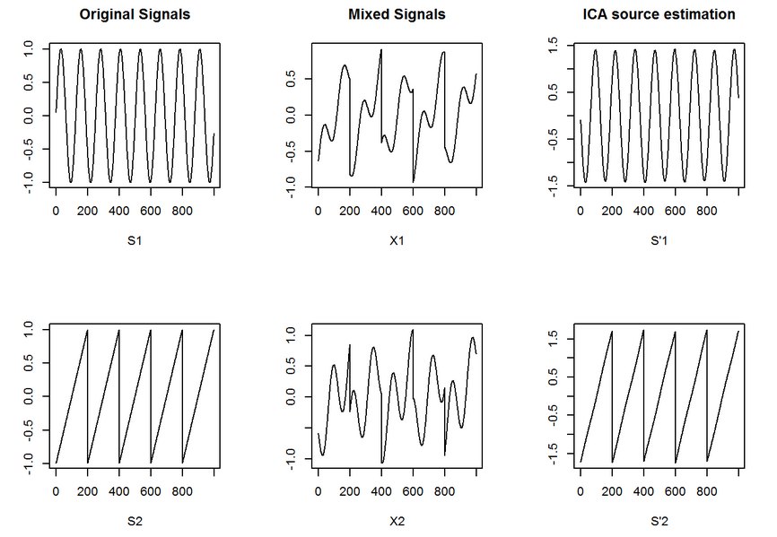

### 選擇多少個來源訊號的數量？

跟主成份分析(PCA)需要決定選多少個主成份(利用「解釋變異」)的概念一樣，一般在使用 ICA 時，也必須知道原始訊號的數量，也就是上面程式的`n.comp`參數。

在實務應用中，一般可以仰賴領域(先驗)知識來決定。例如，你可以確定原始訊號的個數，跟混合訊號一樣。

但如果沒有相關經驗或知識的話，就很難判斷 ICA 中的來源訊號要選幾個。這時候，就得依照某些方法選擇component的數量。

其中，基於information-theoretic criteria (ITC)的資訊理論，是一個不錯且實用的方法：[Estimating the number of independent components for functional magnetic resonance imaging data](https://www.ncbi.nlm.nih.gov/pubmed/17274023)

## 3. 總結

由於 ICA 可以從混合訊號中分離出原始訊號，因此常被用於醫學跟通訊領域的研究中，從蒐集到的電子訊號中找出來源或起因。

此外 ICA 跟 PCA 一樣，都是常用來降維的手法。若由特徵的角度來看，兩者也都是特徵萃取(feature extraction)的演算法，但思維卻不一樣：

「ICA 是從資料中分離出特徵，PCA 則是從資料中結合出特徵」。

但因為原始訊號(component)的數量難以定論，以及原始訊號得為非高斯(常態)分配的假設，因此相較於 PCA ，ICA 在某些運用上被認為不太實用，往往會面臨到一些困境(當然，還是得根據運用的領域跟目的而定)。

因此，使用前要好好先理解兩者的概念，理解優與劣，再根據問題及目標來應用。

It’s still a long way to go~

## 4. Reference

- [ICA, LLE](https://sway.com/8E5AAkpEYq1DdCiH)
- [Independent Component Analysis for dummies](http://arnauddelorme.com/ica_for_dummies/)
- [Dimensional Reduction – ICA](https://ithelp.ithome.com.tw/articles/10188526)
- [雞尾酒會效應](https://info.babyhome.com.tw/article/1688)
- [FastICA Algorithm](https://www.cs.helsinki.fi/u/ahyvarin/papers/fastica.shtml)
- [R Example for ICA Implement](http://rpubs.com/skydome20/93614)
- [Estimating the number of independent components for functional magnetic resonance imaging data](https://www.ncbi.nlm.nih.gov/pubmed/17274023)

## 5. R and packages version

這是本篇筆記使用R跟套件版本：

```r
pkgs = c("fastICA")
r_version = paste("R", getRversion())
pkg_version = c()
for (package_name in pkgs) {
    pkg_version = c(pkg_version,
                    paste(package_name,packageVersion(package_name)))
}
c(r_version, pkg_version)
```

```
## [1] "R 3.4.3"       "fastICA 1.2.1"
```